# Chapter-12-ExerciseSolutions

2022-11-04

```r
head(di)
```

```
##    ...1 carat       cut color clarity depth table price    x    y    z
## 1:    1  0.23     Ideal     E     SI2  61.5    55   326 3.95 3.98 2.43
## 2:    2  0.21   Premium     E     SI1  59.8    61   326 3.89 3.84 2.31
## 3:    3  0.23      Good     E     VS1  56.9    65   327 4.05 4.07 2.31
## 4:    4  0.29   Premium     I     VS2  62.4    58   334 4.20 4.23 2.63
## 5:    5  0.31      Good     J     SI2  63.3    58   335 4.34 4.35 2.75
## 6:    6  0.24 Very Good     J    VVS2  62.8    57   336 3.94 3.96 2.48
```

1.Using the maximum likelihood approach develop a regression model for the outcome variable price based on the independent variables carat, depth, table, x, y, and z.

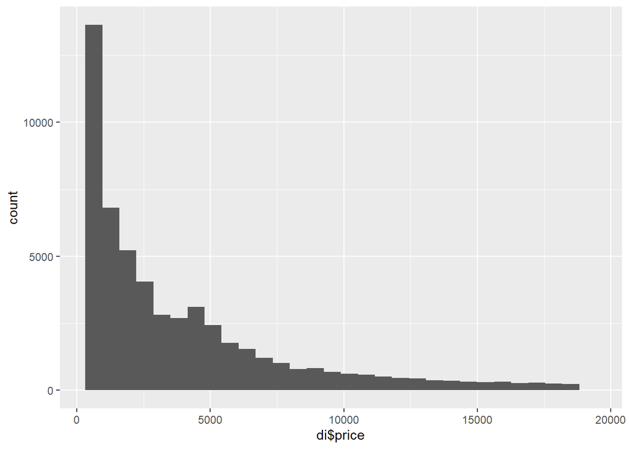

```r
ggplot() +
  geom_histogram(aes(di$price))
```

```r
LLnorm = function(b0,b1,b2,b3,b4,b5,b6, standdev){
  mean1 = b0 + b1*di$carat + b2*di$depth + b3*di$table + b4*di$x + b5*di$y + b6*di$z
  p = dnorm(x = di$price, mean = mean1, sd = standdev)
  LL = sum(log(p))
  return(-1*LL)
}

mle_di = mle2(minuslogl = LLnorm,
            start = list(b0 = 3932,b1 = 0,b2 = 0,b3=0,b4=0,b5=0,b6=0,standdev = 3989))
di$regression_mle = as.matrix(di[,.(carat, depth, table, x, y, z)]) %*%  coef(mle_di)[2:7] + coef(mle_di)[1]
di$regerror_mle = di$price - di$regression_mle

summary(mle_di)
```

```
## Maximum likelihood estimation
##
## Call:
## mle2(minuslogl = LLnorm, start = list(b0 = 3932, b1 = 0, b2 = 0,
##     b3 = 0, b4 = 0, b5 = 0, b6 = 0, standdev = 3989))
##
## Coefficients:
##           Estimate Std. Error  z value                 Pr(z)
## b0       3901.2152   469.7679   8.3046 < 0.00000000000000022 ***
## b1       7361.2040    67.9547 108.3252 < 0.00000000000000022 ***
## b2        -51.1463     5.7049  -8.9654 < 0.00000000000000022 ***
## b3        -61.7494     3.1609 -19.5357 < 0.00000000000000022 ***
## b4        404.0054    45.3411   8.9104 < 0.00000000000000022 ***
## b5        -32.1237    26.0763  -1.2319                 0.218
## b6       -352.8431    45.3219  -7.7853  0.000000000000006957 ***
## standdev 1528.9594     4.8819 313.1915 < 0.00000000000000022 ***
## ---
## Signif. codes:  0 '***' 0.001 '**' 0.01 '*' 0.05 '.' 0.1 ' ' 1
##
## -2 log L: 944914.2
```

```r
lm_di <- lm(price ~ carat + depth + table + x + y + z, data  = di)

di$regression_lm = as.matrix(di[,.(carat, depth, table, x, y, z)]) %*%  coef(lm_di)[2:7] + coef(lm_di)[1]
di$regerror_lm = di$price - di$regression_lm

summary(lm_di)
```

```
##
## Call:
## lm(formula = price ~ carat + depth + table + x + y + z, data = di)
##
## Residuals:
##      Min       1Q   Median       3Q      Max
## -23878.2   -615.0    -50.7    347.9  12759.2
##
## Coefficients:
##              Estimate Std. Error t value             Pr(>|t|)
## (Intercept) 20849.316    447.562  46.584 < 0.0000000000000002 ***
## carat       10686.309     63.201 169.085 < 0.0000000000000002 ***
## depth        -203.154      5.504 -36.910 < 0.0000000000000002 ***
## table        -102.446      3.084 -33.216 < 0.0000000000000002 ***
## x           -1315.668     43.070 -30.547 < 0.0000000000000002 ***
## y              66.322     25.523   2.599              0.00937 **
## z              41.628     44.305   0.940              0.34744
## ---
## Signif. codes:  0 '***' 0.001 '**' 0.01 '*' 0.05 '.' 0.1 ' ' 1
##
## Residual standard error: 1497 on 53933 degrees of freedom
## Multiple R-squared:  0.8592, Adjusted R-squared:  0.8592
## F-statistic: 5.486e+04 on 6 and 53933 DF,  p-value: < 0.00000000000000022
```

2.Compute the SST and SSE values. What is the R2 value?

```r
SST <- sum((di$price - 3932)^2)
SSE <- sum((di$regression_mle - di$price)^2)

Rsquare = 1 - (SSE/SST)
round(Rsquare,3)
```

```
## [1] 0.851
```

```r
SST <- sum((di$price - 3932)^2)
SSE <- sum((di$regression_lm - di$price)^2)

Rsquare = 1 - (SSE/SST)
round(Rsquare,3)
```

```
## [1] 0.859
```

3.Plot the errors and visually examine if the errors are reasonably normal.

4.Based on a visual plot, assess if there is heteroscedasticity in the regression model.

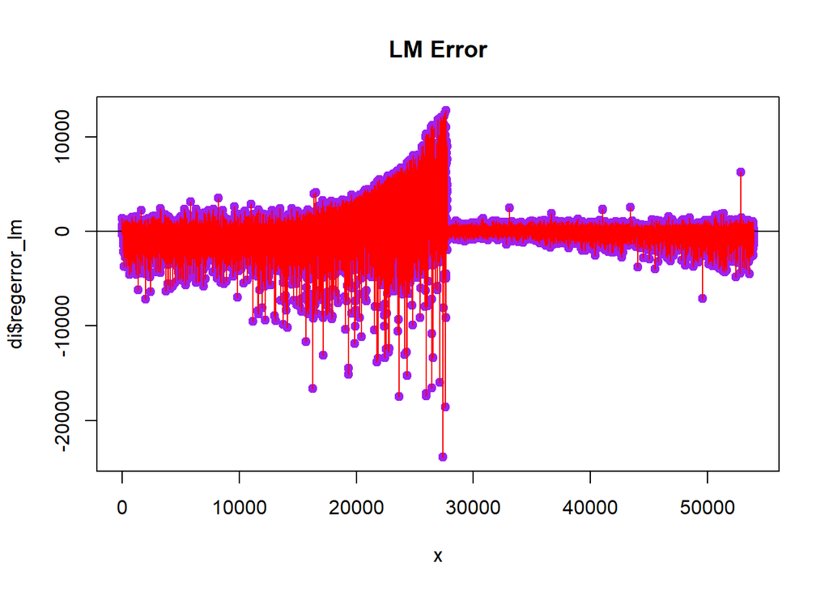

```r
x = seq(1,nrow(di))
plot(x = x, y = di$regerror_lm, col = "purple", pch = 19, main = "LM Error")
abline(h=0)
segments(x,di$regerror_lm,x,0,col = "red")
```

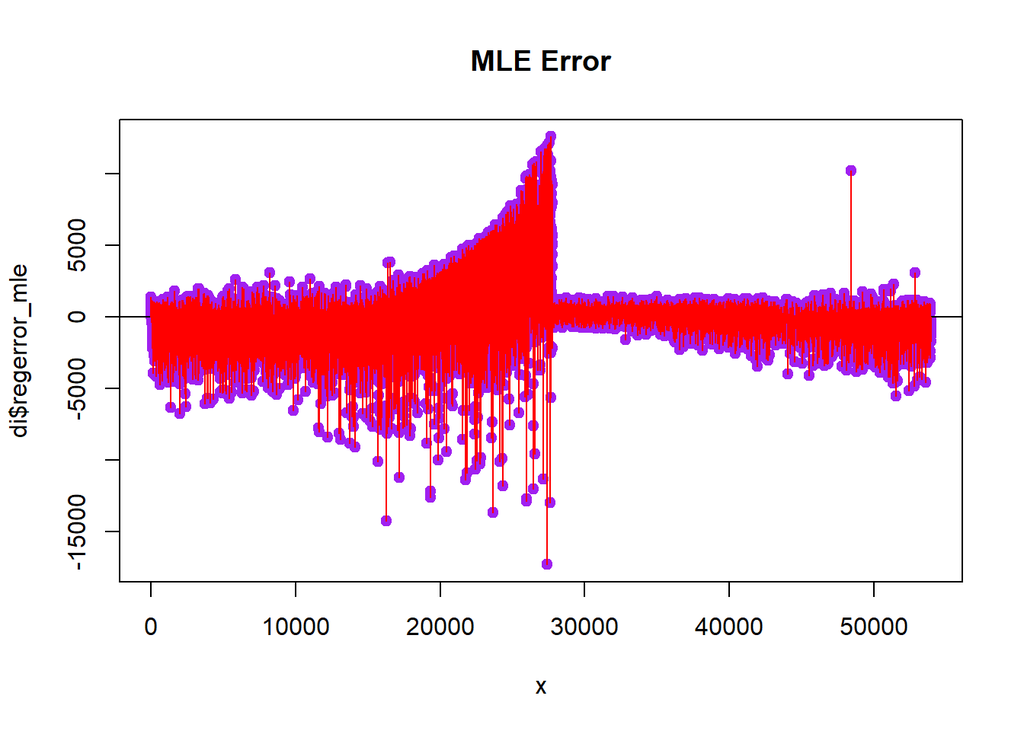

```r
x = seq(1,nrow(di))
plot(x = x, y = di$regerror_mle, col = "purple", pch = 19, main = "MLE Error")
abline(h=0)
segments(x,di$regerror_mle,x,0,col = "red")
```

There does appear to be heteroscedasticity since the values of these error values change drastically

5. Read the file UsedCars2017.csv

Using the maximum likelihood approach develop a regression model for the outcome variable Price based on the other variables in the dataframe.

Compute the SST and SSE values. What is the R2 value?

Plot the errors and visually examine if the errors are reasonably normal.

Based on a visual plot, assess if there is heteroscedasticity in the regression model.

```r
head(uc)
```

```
##    Price Age Mileage MPG KBB_Price CR_Reliability_Score
## 1: 11858   6    69.7  34     10600                 0.80
## 2:  3092  17   166.7  21      2400                 0.67
## 3: 14300   4    42.3  35     11100                 0.75
## 4: 10942   6    84.4  28      8500                 0.92
## 5: 12968   5    56.6  27     10000                 0.56
## 6:  2369  22   168.2  34      1800                 0.59
```

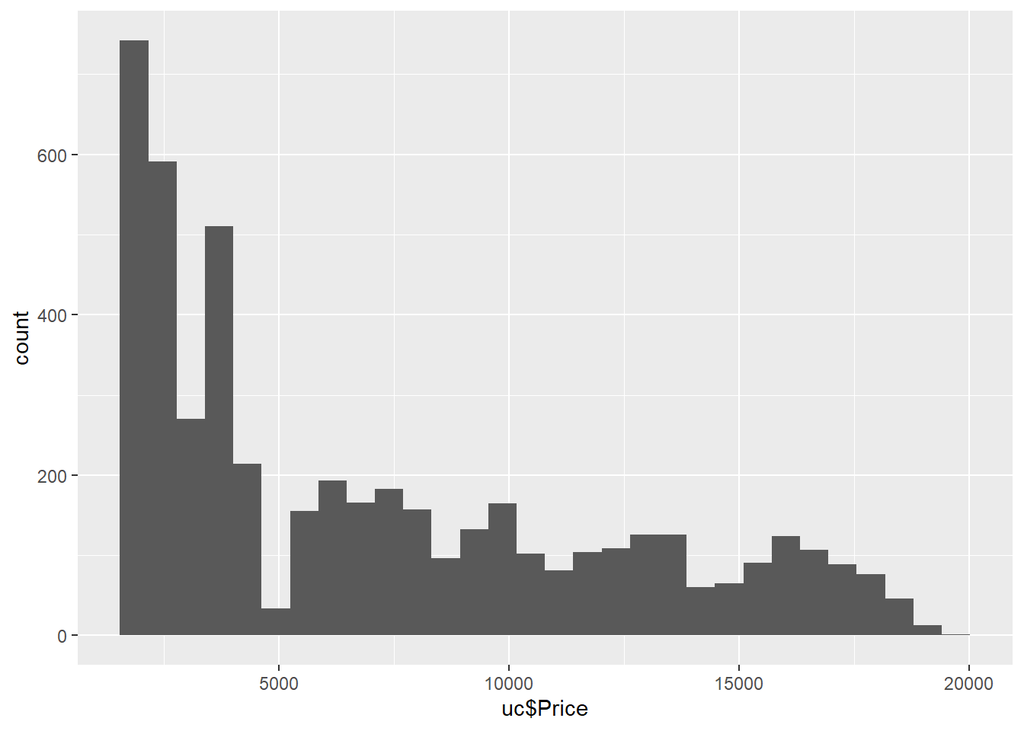

```r
ggplot() +
  geom_histogram(aes(uc$Price))
```

```r
LLnorm = function(b0,b1,b2,b3,b4,b5, standdev){
  mean1 = b0 + b1*uc$Age + b2*uc$Mileage + b3*uc$MPG + b4*uc$KBB_Price + b5*uc$CR_Reliability_Score
  p = dnorm(x = uc$Price, mean = mean1, sd = standdev)
  LL = sum(log(p))
  return(-1*LL)
}

mle_uc = mle2(minuslogl = LLnorm,
            start = list(b0 = mean(uc$Price),b1 = 0,b2 = 0,b3=0,b4=0,b5=0,standdev = sd(uc$Price)))

uc$regression_mle = as.matrix(uc[,.(Age, Mileage, MPG, KBB_Price, CR_Reliability_Score)]) %*%  coef(mle_uc)[2:6] + coef(mle_uc)[1]
uc$regerror_mle = uc$Price - uc$regression_mle

summary(mle_uc)
```

```
## Maximum likelihood estimation
##
## Call:
## mle2(minuslogl = LLnorm, start = list(b0 = mean(uc$Price), b1 = 0,
##     b2 = 0, b3 = 0, b4 = 0, b5 = 0, standdev = sd(uc$Price)))
##
## Coefficients:
##              Estimate   Std. Error     z value                 Pr(z)
## b0       7106.9869062    0.0470874 150931.7085 < 0.00000000000000022 ***
## b1        -55.1839582    2.3378366    -23.6047 < 0.00000000000000022 ***
## b2        -29.7466607    0.2995367    -99.3089 < 0.00000000000000022 ***
## b3          3.3293191    0.7990222      4.1667             0.0000309 ***
## b4          0.7649290    0.0018454    414.4960 < 0.00000000000000022 ***
## b5          7.7760226    0.0322739    240.9382 < 0.00000000000000022 ***
## standdev  382.8072320    3.8561743     99.2712 < 0.00000000000000022 ***
## ---
## Signif. codes:  0 '***' 0.001 '**' 0.01 '*' 0.05 '.' 0.1 ' ' 1
##
## -2 log L: 72602.09
```

```r
lm_uc <- lm(Price ~ Age + Mileage + MPG + KBB_Price + CR_Reliability_Score, data  = uc)

uc$regression_lm = as.matrix(uc[,.(Age, Mileage, MPG, KBB_Price, CR_Reliability_Score)]) %*%  coef(lm_uc)[2:6] + coef(lm_uc)[1]
uc$regerror_lm = uc$Price - uc$regression_lm

summary(lm_uc)
```

```
##
## Call:
## lm(formula = Price ~ Age + Mileage + MPG + KBB_Price + CR_Reliability_Score,
##     data = uc)
##
## Residuals:
##      Min       1Q   Median       3Q      Max
## -2129.26  -216.95   -14.51   211.91  1470.20
##
## Coefficients:
##                         Estimate  Std. Error t value            Pr(>|t|)
## (Intercept)          9737.616657  126.762612  76.818 <0.0000000000000002 ***
## Age                   -55.027893    2.239683 -24.570 <0.0000000000000002 ***
## Mileage               -42.988463    0.689050 -62.388 <0.0000000000000002 ***
## MPG                    -0.140559    0.782932  -0.180               0.858
## KBB_Price               0.599513    0.008016  74.789 <0.0000000000000002 ***
## CR_Reliability_Score  -13.202665   36.065086  -0.366               0.714
## ---
## Signif. codes:  0 '***' 0.001 '**' 0.01 '*' 0.05 '.' 0.1 ' ' 1
##
## Residual standard error: 366.7 on 4922 degrees of freedom
## Multiple R-squared:  0.9946, Adjusted R-squared:  0.9946
## F-statistic: 1.824e+05 on 5 and 4922 DF,  p-value: < 0.00000000000000022
```

2.Compute the SST and SSE values. What is the R2 value?

```r
SST <- sum((uc$Price - 3932)^2)
SSE <- sum((uc$regression_mle - uc$Price)^2)

Rsquare = 1 - (SSE/SST)
round(Rsquare,3)
```

```
## [1] 0.996
```

```r
SST <- sum((uc$Price - 3932)^2)
SSE <- sum((uc$regression_lm - uc$Price)^2)

Rsquare = 1 - (SSE/SST)
round(Rsquare,3)
```

```
## [1] 0.996
```

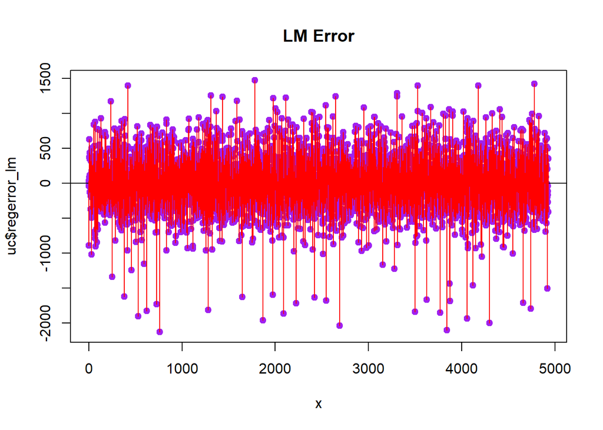

```r
x = seq(1,nrow(uc))
plot(x = x, y = uc$regerror_lm, col = "purple", pch = 19, main = "LM Error")
abline(h=0)
segments(x,uc$regerror_lm,x,0,col = "red")
```

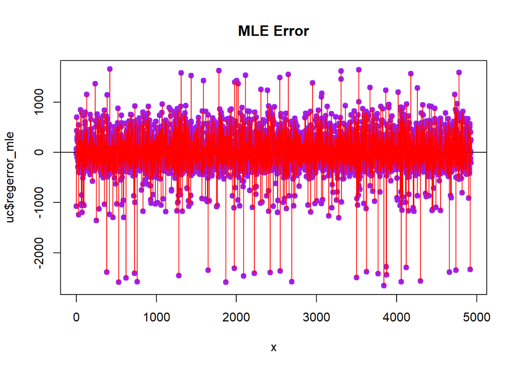

```r
x = seq(1,nrow(uc))
plot(x = x, y = uc$regerror_mle, col = "purple", pch = 19, main = "MLE Error")
abline(h=0)
segments(x,uc$regerror_mle,x,0,col = "red")
```